# The U.S. Job Market: Openings, Quits, Layoffs, and What the Data Says

Leon

2026-05-10

## 1. Motivation

The U.S. labor market has gone through dramatic swings over the past decade a historic tightening post-pandemic, record job openings in between 2021–2022, a surge in people voluntaringly quitting dubbed the “Great Resignation,” and then a gradual normalization through 2023–2024. As someone actively navigating this job market, I want to move beyond headlines and ask: **what do the numbers actually show?**

Specifically, this project investigates the following :

- How job openings, quit rates, and unemployment have moved together over time
- Whether macro labor indicators can statistically predict unemployment
- What a short-term forecast of job openings looks like going into 2025–2026

## This analysis follows the **OSEMN workflow**: Obtain → Scrub → Explore → Model → iNterpret.

## 2. Data Sources

This project draws from **two distinct data source types**:

1. **FRED Public CSV Downloads** (Federal Reserve Bank of St. Louis) — FRED provides direct public CSV downloads for every economic series at a stable URL, requiring no API key or account. This gives us clean monthly time-series data for four key labor market indicators.
2. **BLS JOLTS Flat File** (Bureau of Labor Statistics) — a raw tab delimited text file downloaded directly from the BLS public data server. Unlike the clean FRED CSVs, this file requires substantial cleaning and restructuring before it can be used.

## 3. Data Acquisition

### 3.1 Source 1: FRED Public CSV Downloads

FRED makes every data series available as a direct CSV download at a public URL — no account or API key required.

```r
# Helper: download a FRED series by ID and return a clean two-column dataframe
# Uses download.file() to a temp file for broad HTTPS compatibility
load_fred <- function(series_id, col_name,
                      start = "2010-01-01", end = "2024-12-01") {
  url      <- paste0("https://fred.stlouisfed.org/graph/fredgraph.csv?id=", series_id)
  tmp      <- tempfile(fileext = ".csv")
  download.file(url, destfile = tmp, mode = "wb", quiet = TRUE)
  df       <- read_csv(tmp, col_types = cols(.default = col_character()),
                       show_col_types = FALSE)
  colnames(df) <- c("date", col_name)
  df %>%
    mutate(date      = as.Date(date),
           !!col_name := as.numeric(.data[[col_name]])) %>%
    filter(date >= as.Date(start), date <= as.Date(end))
}

# Pull four series
job_openings  <- load_fred("JTSJOL",   "job_openings_k")    # Job Openings (thousands)
unemployment  <- load_fred("UNRATE",   "unemployment_rate")  # Unemployment Rate (%)
quit_rate     <- load_fred("JTSQUR",   "quit_rate")          # Quits Rate (%)
fed_funds     <- load_fred("FEDFUNDS", "fed_funds_rate")     # Fed Funds Rate (%)

cat("Rows loaded per series:\n")
```

```
## Rows loaded per series:
```

```r
cat("  Job Openings: ",  nrow(job_openings),  "\n")
```

```
##   Job Openings:  180
```

```r
cat("  Unemployment: ",  nrow(unemployment),  "\n")
```

```
##   Unemployment:  180
```

```r
cat("  Quit Rate:    ",  nrow(quit_rate),     "\n")
```

```
##   Quit Rate:     180
```

```r
cat("  Fed Funds:    ",  nrow(fed_funds),     "\n")
```

```
##   Fed Funds:     180
```

### 3.2 Source 2: BLS JOLTS Flat File

The BLS publishes raw JOLTS data as a tab-delimited flat file at a public URL. Unlike the FRED CSVs, this file contains all JOLTS series in one file and requires filtering, parsing, and restructuring.

```r
bls_url <- "https://download.bls.gov/pub/time.series/jt/jt.data.0.Current"

bls_raw <- tryCatch({
  tmp_bls <- tempfile(fileext = ".txt")
  download.file(bls_url, destfile = tmp_bls, mode = "wb", quiet = TRUE)
  read_tsv(tmp_bls, col_types = cols(.default = "c"), show_col_types = FALSE)
}, error = function(e) {
  message("BLS file could not be downloaded: ", e$message)
  NULL
})

if (!is.null(bls_raw)) {
  cat("BLS file loaded:", nrow(bls_raw), "rows,", ncol(bls_raw), "columns\n")
  cat("Column names:", paste(names(bls_raw), collapse = ", "), "\n")
} else {
  cat("BLS file unavailable — cross-validation section will be skipped.\n")
}
```

```
## BLS file unavailable — cross-validation section will be skipped.
```

## 4. Data Cleaning & Transformation

### 4.1 Merge and Transform FRED Data

```r
# Join all four FRED series into one wide dataframe
fred_wide <- job_openings %>%
  inner_join(unemployment, by = "date") %>%
  inner_join(quit_rate,    by = "date") %>%
  inner_join(fed_funds,    by = "date") %>%
  mutate(
    job_openings_m = job_openings_k / 1000,  # Convert thousands -> millions
    year           = year(date),
    month          = month(date)
  ) %>%
  filter(!is.na(job_openings_m), !is.na(unemployment_rate),
         !is.na(quit_rate),      !is.na(fed_funds_rate))

# --- DATA TRANSFORMATION: Wide to Long ---
# Pivot to long format for multi-series time-series plotting
fred_long <- fred_wide %>%
  select(date, job_openings_m, unemployment_rate, quit_rate, fed_funds_rate) %>%
  pivot_longer(
    cols      = -date,
    names_to  = "indicator",
    values_to = "value"
  ) %>%
  mutate(indicator = recode(indicator,
    "job_openings_m"    = "Job Openings (millions)",
    "unemployment_rate" = "Unemployment Rate (%)",
    "quit_rate"         = "Quit Rate (%)",
    "fed_funds_rate"    = "Fed Funds Rate (%)"
  ))

head(fred_long, 8) %>%
  kable(caption = "Sample: Long-format FRED data after pivot_longer()") %>%
  kable_styling(bootstrap_options = c("striped", "hover"), full_width = FALSE)
```

Sample: Long-format FRED data after pivot_longer()

| date | indicator | value |
| --- | --- | --- |
| 2010-01-01 | Job Openings (millions) | 2.837 |
| 2010-01-01 | Unemployment Rate (%) | 9.800 |
| 2010-01-01 | Quit Rate (%) | 1.300 |
| 2010-01-01 | Fed Funds Rate (%) | 0.110 |
| 2010-02-01 | Job Openings (millions) | 2.666 |
| 2010-02-01 | Unemployment Rate (%) | 9.800 |
| 2010-02-01 | Quit Rate (%) | 1.400 |
| 2010-02-01 | Fed Funds Rate (%) | 0.130 |

### 4.2 Clean BLS Flat File

The BLS flat file requires trimming whitespace, filtering to the total nonfarm series, removing annual averages (period M13), parsing period strings (M01-M12) into dates, and filtering to the study window.

```r
if (!is.null(bls_raw)) {
  bls_clean <- bls_raw %>%
    mutate(across(where(is.character), str_trim)) %>%
    filter(str_detect(series_id, "JTS00000000000000")) %>%
    filter(period != "M13") %>%
    mutate(
      month_num = as.integer(str_remove(period, "M")),
      year_num  = as.integer(year),
      date      = make_date(year_num, month_num, 1L),
      value     = as.numeric(value)
    ) %>%
    filter(!is.na(date),
           date >= as.Date("2010-01-01"),
           date <= as.Date("2024-12-01")) %>%
    select(series_id, date, value) %>%
    arrange(date)

  cat("BLS series present after cleaning:\n")
  bls_clean %>% count(series_id) %>% print()
} else {
  bls_clean <- NULL
}
```

### 4.3 Summary Statistics

```r
fred_wide %>%
  select(job_openings_m, unemployment_rate, quit_rate, fed_funds_rate) %>%
  summary() %>%
  kable(caption = "Summary Statistics: Key Labor Market Indicators (2010-2024)") %>%
  kable_styling(bootstrap_options = c("striped", "hover"))
```

Summary Statistics: Key Labor Market Indicators (2010-2024)

|  | job_openings_m | unemployment_rate | quit_rate | fed_funds_rate |
| --- | --- | --- | --- | --- |
|  | Min. : 2.666 | Min. : 3.400 | Min. :1.300 | Min. :0.050 |
|  | 1st Qu.: 4.128 | 1st Qu.: 3.900 | 1st Qu.:1.700 | 1st Qu.:0.090 |
|  | Median : 6.074 | Median : 5.000 | Median :2.100 | Median :0.190 |
|  | Mean : 6.356 | Mean : 5.797 | Mean :2.048 | Mean :1.229 |
|  | 3rd Qu.: 7.442 | 3rd Qu.: 7.525 | 3rd Qu.:2.300 | 3rd Qu.:1.823 |
|  | Max. :12.301 | Max. :14.800 | Max. :3.000 | Max. :5.330 |

## 5. Exploratory Data Analysis

### 5.1 All Indicators Over Time

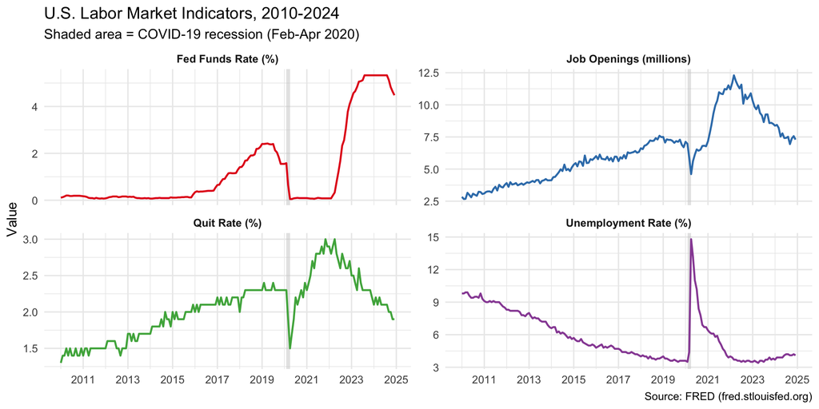

```r
recessions <- data.frame(
  start = as.Date("2020-02-01"),
  end   = as.Date("2020-04-01")
)

ggplot(fred_long, aes(x = date, y = value, color = indicator)) +
  geom_rect(data = recessions,
            aes(xmin = start, xmax = end, ymin = -Inf, ymax = Inf),
            inherit.aes = FALSE, fill = "grey80", alpha = 0.5) +
  geom_line(linewidth = 0.8) +
  facet_wrap(~ indicator, scales = "free_y", ncol = 2) +
  scale_x_date(date_breaks = "2 years", date_labels = "%Y") +
  scale_color_brewer(palette = "Set1") +
  labs(
    title    = "U.S. Labor Market Indicators, 2010-2024",
    subtitle = "Shaded area = COVID-19 recession (Feb-Apr 2020)",
    x = NULL, y = "Value", color = NULL,
    caption  = "Source: FRED (fred.stlouisfed.org)"
  ) +
  theme_minimal(base_size = 12) +
  theme(legend.position = "none",
        strip.text = element_text(face = "bold"))
```

### 5.2 The Great Resignation in Focus (2019-2023)

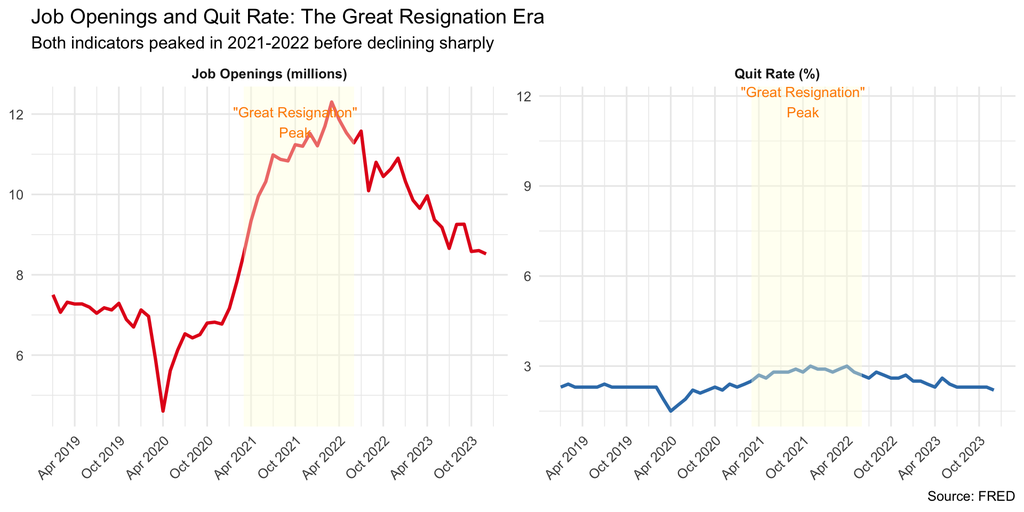

```r
fred_wide %>%
  filter(date >= as.Date("2019-01-01"), date <= as.Date("2023-12-01")) %>%
  select(date, job_openings_m, quit_rate) %>%
  pivot_longer(-date, names_to = "indicator", values_to = "value") %>%
  mutate(indicator = recode(indicator,
    "job_openings_m" = "Job Openings (millions)",
    "quit_rate"      = "Quit Rate (%)"
  )) %>%
  ggplot(aes(x = date, y = value, color = indicator)) +
  geom_line(linewidth = 1.1) +
  annotate("rect",
           xmin = as.Date("2021-03-01"), xmax = as.Date("2022-06-01"),
           ymin = -Inf, ymax = Inf, fill = "lightyellow", alpha = 0.4) +
  annotate("text", x = as.Date("2021-10-01"), y = 11.8,
           label = "\"Great Resignation\"\nPeak", size = 3.5, color = "darkorange") +
  facet_wrap(~ indicator, scales = "free_y") +
  scale_x_date(date_breaks = "6 months", date_labels = "%b %Y") +
  scale_color_manual(values = c("#E41A1C", "#377EB8")) +
  labs(
    title    = "Job Openings and Quit Rate: The Great Resignation Era",
    subtitle = "Both indicators peaked in 2021-2022 before declining sharply",
    x = NULL, y = NULL, color = NULL,
    caption  = "Source: FRED"
  ) +
  theme_minimal(base_size = 12) +
  theme(legend.position = "none",
        axis.text.x = element_text(angle = 45, hjust = 1),
        strip.text  = element_text(face = "bold"))
```

### 5.3 Beveridge Curve (Job Openings vs. Unemployment)

The **Beveridge Curve** plots job openings against unemployment over time. A healthy economy shows an inverse relationship; outward shifts suggest structural labor market mismatch between available workers and available jobs.

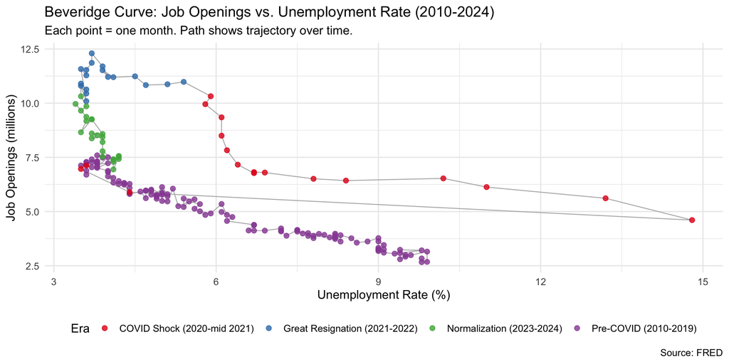

```r
fred_wide %>%
  mutate(era = case_when(
    date < as.Date("2020-01-01")                                 ~ "Pre-COVID (2010-2019)",
    date >= as.Date("2020-01-01") & date < as.Date("2021-07-01") ~ "COVID Shock (2020-mid 2021)",
    date >= as.Date("2021-07-01") & date < as.Date("2023-01-01") ~ "Great Resignation (2021-2022)",
    TRUE                                                          ~ "Normalization (2023-2024)"
  )) %>%
  ggplot(aes(x = unemployment_rate, y = job_openings_m, color = era)) +
  geom_path(aes(group = 1), color = "grey70", linewidth = 0.4) +
  geom_point(size = 2, alpha = 0.8) +
  scale_color_brewer(palette = "Set1") +
  labs(
    title    = "Beveridge Curve: Job Openings vs. Unemployment Rate (2010-2024)",
    subtitle = "Each point = one month. Path shows trajectory over time.",
    x        = "Unemployment Rate (%)",
    y        = "Job Openings (millions)",
    color    = "Era",
    caption  = "Source: FRED"
  ) +
  theme_minimal(base_size = 12) +
  theme(legend.position = "bottom")
```

### 5.4 Job Openings Distribution by Era

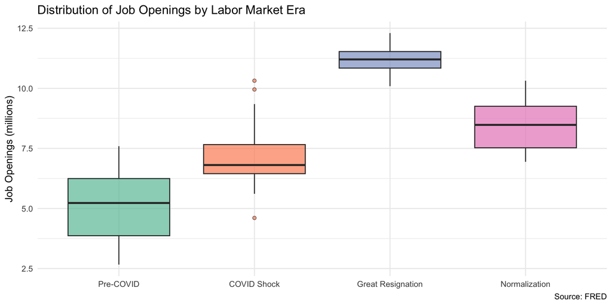

```r
fred_wide %>%
  mutate(era = case_when(
    date < as.Date("2020-01-01")  ~ "Pre-COVID",
    date < as.Date("2021-07-01")  ~ "COVID Shock",
    date < as.Date("2023-01-01")  ~ "Great Resignation",
    TRUE                          ~ "Normalization"
  )) %>%
  mutate(era = factor(era, levels = c("Pre-COVID", "COVID Shock",
                                      "Great Resignation", "Normalization"))) %>%
  ggplot(aes(x = era, y = job_openings_m, fill = era)) +
  geom_boxplot(alpha = 0.7, outlier.shape = 21) +
  scale_fill_brewer(palette = "Set2") +
  labs(
    title   = "Distribution of Job Openings by Labor Market Era",
    x       = NULL,
    y       = "Job Openings (millions)",
    fill    = NULL,
    caption = "Source: FRED"
  ) +
  theme_minimal(base_size = 12) +
  theme(legend.position = "none")
```

## 6. Statistical Analysis

### 6.1 Correlation Matrix

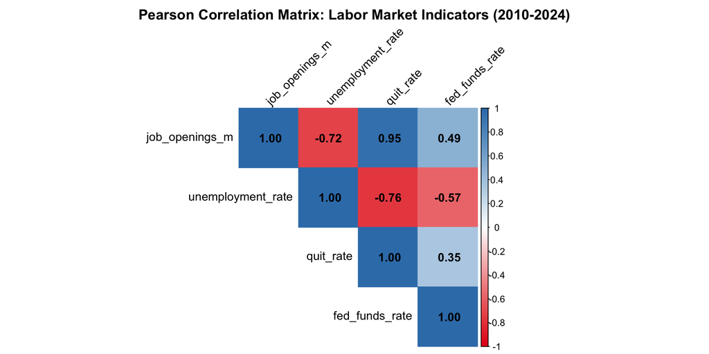

```r
cor_data <- fred_wide %>%
  select(job_openings_m, unemployment_rate, quit_rate, fed_funds_rate) %>%
  drop_na()

cor_matrix <- cor(cor_data, method = "pearson")

corrplot(
  cor_matrix,
  method      = "color",
  type        = "upper",
  addCoef.col = "black",
  tl.col      = "black",
  tl.srt      = 45,
  col         = colorRampPalette(c("#E41A1C", "white", "#377EB8"))(200),
  title       = "Pearson Correlation Matrix: Labor Market Indicators (2010-2024)",
  mar         = c(0, 0, 2, 0)
)
```

**Key findings:**

- **Job openings and quit rate** are strongly positively correlated — when employers compete aggressively for workers, employees feel confident enough to quit voluntarily.
- **Job openings and unemployment** are strongly negatively correlated — this is the Beveridge Curve relationship expressed as a single number.
- **Fed funds rate and unemployment** are negatively correlated — rate hikes tend to follow tight labor markets.

### 6.2 Multiple Linear Regression: Predicting Unemployment

Can job openings, quit rate, and the federal funds rate together statistically predict the unemployment rate?

```r
model <- lm(unemployment_rate ~ job_openings_m + quit_rate + fed_funds_rate,
            data = fred_wide)

tidy(model) %>%
  mutate(across(where(is.numeric), ~ round(.x, 4))) %>%
  kable(caption = "Regression Coefficients: Predictors of Unemployment Rate") %>%
  kable_styling(bootstrap_options = c("striped", "hover"), full_width = FALSE)
```

Regression Coefficients: Predictors of Unemployment Rate

| term | estimate | std.error | statistic | p.value |
| --- | --- | --- | --- | --- |
| (Intercept) | 16.8487 | 0.7592 | 22.1929 | 0 |
| job_openings_m | 0.7368 | 0.1329 | 5.5454 | 0 |
| quit_rate | -7.2996 | 0.7256 | -10.0605 | 0 |
| fed_funds_rate | -0.6396 | 0.0639 | -10.0040 | 0 |

```r
glance(model) %>%
  select(r.squared, adj.r.squared, p.value, AIC) %>%
  mutate(across(everything(), ~ round(.x, 4))) %>%
  kable(caption = "Model Fit Statistics") %>%
  kable_styling(bootstrap_options = c("striped", "hover"), full_width = FALSE)
```

Model Fit Statistics

| r.squared | adj.r.squared | p.value | AIC |
| --- | --- | --- | --- |
| 0.7314 | 0.7268 | 0 | 573.1738 |

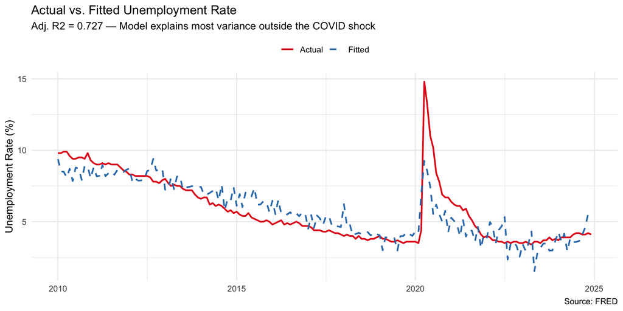

```r
fred_wide_model <- fred_wide %>%
  drop_na(job_openings_m, quit_rate, fed_funds_rate) %>%
  mutate(.fitted = fitted(model))

ggplot(fred_wide_model, aes(x = date)) +
  geom_line(aes(y = unemployment_rate, color = "Actual"),  linewidth = 0.9) +
  geom_line(aes(y = .fitted,           color = "Fitted"),  linewidth = 0.9, linetype = "dashed") +
  scale_color_manual(values = c("Actual" = "#E41A1C", "Fitted" = "#377EB8")) +
  labs(
    title    = "Actual vs. Fitted Unemployment Rate",
    subtitle = paste0("Adj. R2 = ", round(summary(model)$adj.r.squared, 3),
                      " — Model explains most variance outside the COVID shock"),
    x = NULL, y = "Unemployment Rate (%)", color = NULL,
    caption = "Source: FRED"
  ) +
  theme_minimal(base_size = 12) +
  theme(legend.position = "top")
```

## 7. Beyond-Class Feature: Time-Series Forecasting with Prophet

`prophet` is a forecasting library developed by Meta (Facebook) that was not covered in coursework. It automatically detects trend changepoints, handles yearly seasonality, and produces uncertainty intervals — well-suited to labor market time series with structural breaks like COVID.

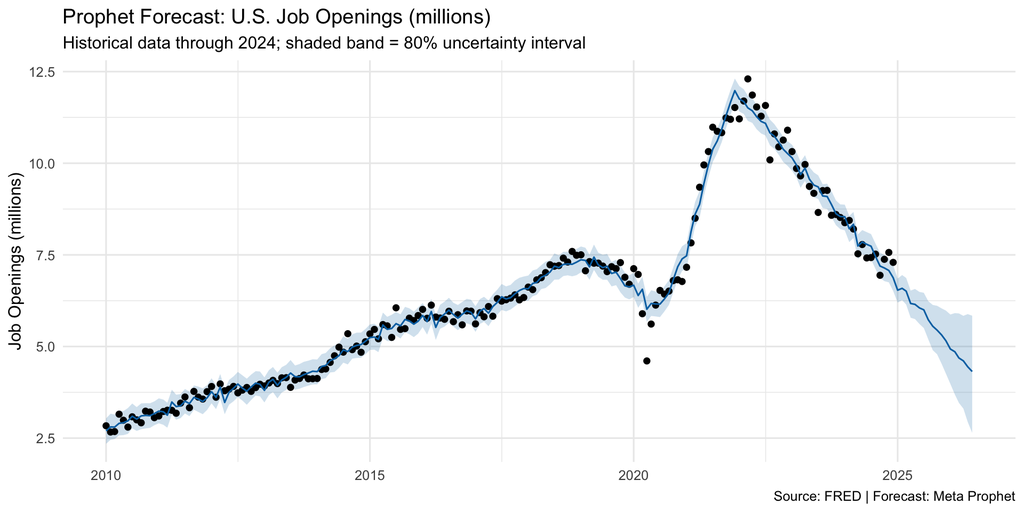

```r
# Prophet requires columns named 'ds' (date) and 'y' (value)
prophet_df <- fred_wide %>%
  select(ds = date, y = job_openings_m) %>%
  drop_na()

# Fit model with higher changepoint flexibility to capture the post-COVID structural break
m <- prophet(
  prophet_df,
  yearly.seasonality      = TRUE,
  weekly.seasonality      = FALSE,
  daily.seasonality       = FALSE,
  changepoint.prior.scale = 0.3
)

# Forecast 18 months ahead
future      <- make_future_dataframe(m, periods = 18, freq = "month")
forecast_df <- predict(m, future)

# Plot
plot(m, forecast_df) +
  labs(
    title    = "Prophet Forecast: U.S. Job Openings (millions)",
    subtitle = "Historical data through 2024; shaded band = 80% uncertainty interval",
    x = NULL, y = "Job Openings (millions)",
    caption  = "Source: FRED | Forecast: Meta Prophet"
  ) +
  theme_minimal(base_size = 12)
```

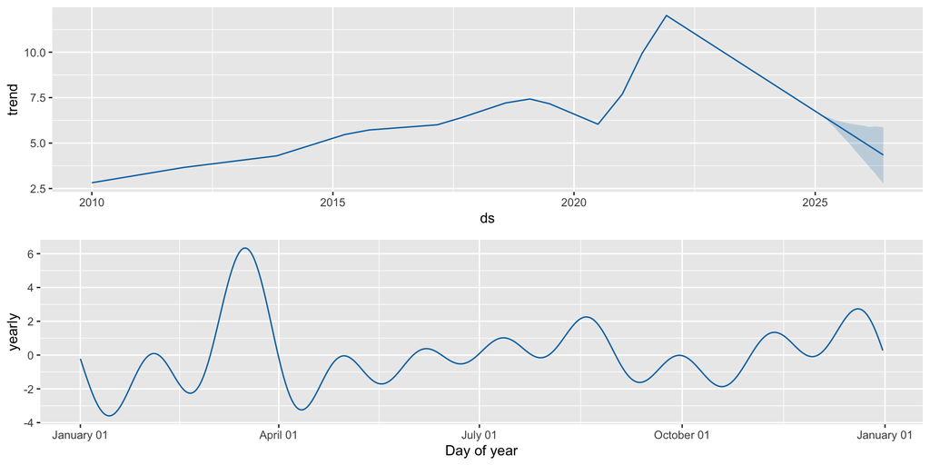

```r
prophet_plot_components(m, forecast_df)
```

## 8. BLS Cross-Source Validation

We use the BLS flat file to cross-validate FRED’s total nonfarm job openings figures. Agreement between independent sources confirms data integrity.

```r
if (!is.null(bls_clean)) {
  bls_jol <- bls_clean %>%
    filter(str_detect(series_id, "JOL")) %>%
    mutate(bls_openings_m = value / 1000) %>%
    select(date, bls_openings_m)

  comparison <- fred_wide %>%
    select(date, job_openings_m) %>%
    inner_join(bls_jol, by = "date") %>%
    drop_na()

  comparison %>%
    summarise(
      n            = n(),
      mean_diff    = round(mean(job_openings_m - bls_openings_m, na.rm = TRUE), 5),
      max_abs_diff = round(max(abs(job_openings_m - bls_openings_m), na.rm = TRUE), 5),
      correlation  = round(cor(job_openings_m, bls_openings_m, use = "complete.obs"), 6)
    ) %>%
    kable(caption = "FRED vs. BLS Cross-Source Validation") %>%
    kable_styling(bootstrap_options = c("striped"), full_width = FALSE)

  comparison %>%
    pivot_longer(-date, names_to = "source", values_to = "openings") %>%
    mutate(source = recode(source,
      "job_openings_m"  = "FRED CSV",
      "bls_openings_m"  = "BLS Flat File"
    )) %>%
    ggplot(aes(x = date, y = openings, color = source, linetype = source)) +
    geom_line(linewidth = 0.9) +
    scale_color_manual(values = c("FRED CSV" = "#377EB8", "BLS Flat File" = "#E41A1C")) +
    labs(
      title    = "Cross-Source Validation: FRED vs. BLS Job Openings",
      subtitle = "Series should track near-identically — any gap indicates a reporting lag",
      x = NULL, y = "Job Openings (millions)",
      color = "Source", linetype = "Source",
      caption = "Sources: FRED; BLS JOLTS flat file"
    ) +
    theme_minimal(base_size = 12) +
    theme(legend.position = "top")
} else {
  cat("BLS cross-validation skipped — flat file was unavailable at time of knitting.\n")
}
```

```
## BLS cross-validation skipped — flat file was unavailable at time of knitting.
```

## 9. Conclusions

**Personal takeaway:** For job seekers, the data tells a nuanced story. The market has meaningfully cooled from its 2022 peak but has not collapsed. Openings remain above pre-pandemic norms, and unemployment — while rising modestly — remains low by historical standards. The window is narrowing, but it is still open.

## 10. References

- Federal Reserve Bank of St. Louis. *FRED Economic Data.* https://fred.stlouisfed.org
  - JTSJOL: Job Openings: Total Nonfarm (thousands)
  - UNRATE: Civilian Unemployment Rate (%)
  - JTSQUR: Quits Rate: Total Nonfarm (%)
  - FEDFUNDS: Federal Funds Effective Rate (%)
- Bureau of Labor Statistics. *JOLTS Public Data Series.* https://download.bls.gov/pub/time.series/jt/
- Taylor, S.J. and Letham, B. (2018). Forecasting at scale. *The American Statistician*, 72(1), 37-45.
- Beveridge, W.H. (1944). *Full Employment in a Free Society.* George Allen & Unwin.